# 5. Comorbidity Sensitivity Analysis (GEE): fallback_emo_ace

Sam A. Sievertsen

## Overview

Goal: test whether baseline-derived *BD risk clusters* carry unique BD-specific signal (vs a broader, transdiagnostic signal) by modeling longitudinal diagnostic group membership:

- any_bsd (replicate prior BD occurrence logic, but using the validated KSADS-derived BSD indicator)
- dx_other_any (any comorbidity umbrella dx)
- dx_group4 contrasts vs *No Dx*:
  - BSD only vs No Dx
  - BSD + other Dx vs No Dx
  - Other Dx only (no BSD) vs No Dx

Primary approach: marginal logistic GEE (geepack::geeglm), `cluster x wave`, with your existing covariates and (optionally) baseline-status adjustment. We keep the same “GEE-by-wave ORs” workflow via emmeans as your prior scripts.

Disorder-specific models (Reviewer 1, comment 4): the same occurrence GEE is fit separately for each comorbidity set (ADHD, anxiety disorders, depressive disorders, PTSD, ODD/CD), and a stacked GEE across BSD and all five sets formally tests whether the cluster effect for BSD differs from the cluster effect for each comorbidity (ratios of odds ratios).

> Note on sparse cells: BSD-only at ses-02A is extremely rare (n~3). The script includes a guardrail to drop wave(s) with very low event counts *for that outcome only* (default threshold = 5), and refactors the wave reference level for sparse outcomes (default = ses-04A).

## 1. Read + Merge Datasets

```
#1 Data merge summary
```

```
panel rows (raw): 103072
```

```
panel rows (person-wave): 25768
```

```
supp rows (person-wave): 68190
```

```
merged rows: 68190
```

## 2. Quick QC Tables

QC: dx_group4 by wave x cluster (analytic waves; observed only)

| wave | cluster | dx_group4 | n | pct |
| --- | --- | --- | --- | --- |
| ses-02A | Lower-Risk | BSD + other Dx | 37 | 0.006 |
| ses-02A | Lower-Risk | BSD only | 2 | 0.000 |
| ses-02A | Lower-Risk | No Dx (Dx-set of interest) | 4865 | 0.748 |
| ses-02A | Lower-Risk | Other Dx only (no BSD) | 1604 | 0.246 |
| ses-02A | Higher-Risk | BSD + other Dx | 66 | 0.035 |
| ses-02A | Higher-Risk | BSD only | 1 | 0.001 |
| ses-02A | Higher-Risk | No Dx (Dx-set of interest) | 818 | 0.431 |
| ses-02A | Higher-Risk | Other Dx only (no BSD) | 1014 | 0.534 |
| ses-04A | Lower-Risk | BSD + other Dx | 105 | 0.019 |
| ses-04A | Lower-Risk | BSD only | 50 | 0.009 |
| ses-04A | Lower-Risk | No Dx (Dx-set of interest) | 4022 | 0.712 |
| ses-04A | Lower-Risk | Other Dx only (no BSD) | 1468 | 0.260 |
| ses-04A | Higher-Risk | BSD + other Dx | 58 | 0.037 |
| ses-04A | Higher-Risk | BSD only | 10 | 0.006 |
| ses-04A | Higher-Risk | No Dx (Dx-set of interest) | 802 | 0.510 |
| ses-04A | Higher-Risk | Other Dx only (no BSD) | 702 | 0.447 |
| ses-06A | Lower-Risk | BSD + other Dx | 71 | 0.023 |
| ses-06A | Lower-Risk | BSD only | 21 | 0.007 |
| ses-06A | Lower-Risk | No Dx (Dx-set of interest) | 2048 | 0.656 |
| ses-06A | Lower-Risk | Other Dx only (no BSD) | 980 | 0.314 |
| ses-06A | Higher-Risk | BSD + other Dx | 40 | 0.045 |
| ses-06A | Higher-Risk | BSD only | 5 | 0.006 |
| ses-06A | Higher-Risk | No Dx (Dx-set of interest) | 405 | 0.458 |
| ses-06A | Higher-Risk | Other Dx only (no BSD) | 434 | 0.491 |

QC: Non-missing denominators by wave (analytic waves)

| wave | n | n_any_bsd_nonmiss | n_other_any_nonmiss | n_dx_group4_nonmiss |
| --- | --- | --- | --- | --- |
| ses-02A | 8407 | 8407 | 8407 | 8407 |
| ses-04A | 7496 | 7217 | 7217 | 7217 |
| ses-06A | 4018 | 4004 | 4004 | 4004 |

## 3. Define Outcomes and Contrast Datasets

We treat `dx_group4` as a multiclass variable, but (to keep the workflow identical to prior binary GEE scripts) we model pairwise binary contrasts vs No Dx by creating contrast-specific datasets.

QC: Event counts by wave per outcome (analytic waves; excludes NA)

| wave | outcome | n | n_events |
| --- | --- | --- | --- |
| ses-02A | any_bsd | 8407 | 106 |
| ses-04A | any_bsd | 7217 | 223 |
| ses-06A | any_bsd | 4004 | 137 |
| ses-02A | dx_other_any | 8407 | 2721 |
| ses-04A | dx_other_any | 7217 | 2333 |
| ses-06A | dx_other_any | 4004 | 1525 |
| ses-02A | bsd_only_vs_nodx | 5686 | 3 |
| ses-04A | bsd_only_vs_nodx | 4884 | 60 |
| ses-06A | bsd_only_vs_nodx | 2479 | 26 |
| ses-02A | bsd_plus_other_vs_nodx | 5786 | 103 |
| ses-04A | bsd_plus_other_vs_nodx | 4987 | 163 |
| ses-06A | bsd_plus_other_vs_nodx | 2564 | 111 |
| ses-02A | other_only_vs_nodx | 8301 | 2618 |
| ses-04A | other_only_vs_nodx | 6994 | 2170 |
| ses-06A | other_only_vs_nodx | 3867 | 1414 |
| ses-04A | bsd_plus_vs_other_only | 2333 | 163 |
| ses-02A | bsd_plus_vs_other_only | 2721 | 103 |
| ses-06A | bsd_plus_vs_other_only | 1525 | 111 |
| ses-04A | bsd_only_vs_other_only | 2230 | 60 |
| ses-02A | bsd_only_vs_other_only | 2621 | 3 |
| ses-06A | bsd_only_vs_other_only | 1440 | 26 |
| ses-04A | bsd_plus_vs_bsd_only | 223 | 163 |
| ses-02A | bsd_plus_vs_bsd_only | 106 | 103 |
| ses-06A | bsd_plus_vs_bsd_only | 137 | 111 |
| ses-02A | set_adhd | 8407 | 1059 |
| ses-04A | set_adhd | 6469 | 565 |
| ses-06A | set_adhd | 3929 | 377 |
| ses-02A | set_anxiety | 8407 | 1173 |
| ses-04A | set_anxiety | 6540 | 1090 |
| ses-06A | set_anxiety | 4004 | 966 |
| ses-02A | set_depressive | 8407 | 543 |
| ses-04A | set_depressive | 6995 | 1210 |
| ses-06A | set_depressive | 3961 | 436 |
| ses-02A | set_ptsd | 8407 | 161 |
| ses-04A | set_ptsd | 6469 | 180 |
| ses-06A | set_ptsd | 4004 | 326 |
| ses-02A | set_odd_cd | 8407 | 1126 |
| ses-04A | set_odd_cd | 6498 | 626 |

## 4. Helper Functions

## 5. Fit GEE Models + Summarize ORs

```
================ Outcome: any_bsd (wave_ref=ses-02A) ================
Call:
geepack::geeglm(formula = fml, family = binomial(), data = df0,
    id = df0$participant_id, corstr = params$corstr, std.err = "san.se")

 Coefficients:
                                Estimate   Std.err     Wald
(Intercept)                    -4.476146  0.204760 477.8773
clusterHigher-Risk              1.776402  0.201697  77.5684
waveses-04A                     1.082637  0.247074  19.2005
waveses-06A                     0.743188  0.375047   3.9267
sexMale                        -0.714412  0.100040  50.9974
age_wave_gmc                    0.222927  0.077932   8.1825
baseline_status                 1.048413  0.236534  19.6462
clusterHigher-Risk:waveses-04A -1.328905  0.243922  29.6814
clusterHigher-Risk:waveses-06A -1.205796  0.274546  19.2893
                                            Pr(>|W|)
(Intercept)                    < 0.00000000000000022 ***
clusterHigher-Risk             < 0.00000000000000022 ***
waveses-04A                       0.0000117684287072 ***
waveses-06A                                  0.04753 *
sexMale                           0.0000000000009248 ***
age_wave_gmc                                 0.00423 **
baseline_status                   0.0000093189241308 ***
clusterHigher-Risk:waveses-04A    0.0000000509215818 ***
clusterHigher-Risk:waveses-06A    0.0000112335193642 ***
---
Signif. codes:  0 '***' 0.001 '**' 0.01 '*' 0.05 '.' 0.1 ' ' 1

Correlation structure = exchangeable
Estimated Scale Parameters:

            Estimate Std.err
(Intercept)  0.96422 0.60528
  Link = identity

Estimated Correlation Parameters:
      Estimate Std.err
alpha 0.037882 0.02751
Number of clusters:   8559  Maximum cluster size: 3
```

[output cut: 375 more lines]

```
clusterHigher-Risk:waveses-04A  -0.1903  0.1102   2.98              0.08427 .
---
Signif. codes:  0 '***' 0.001 '**' 0.01 '*' 0.05 '.' 0.1 ' ' 1

Correlation structure = exchangeable
Estimated Scale Parameters:

            Estimate Std.err
(Intercept)    0.996   0.105
  Link = identity

Estimated Correlation Parameters:
      Estimate Std.err
alpha    0.232  0.0327
Number of clusters:   8513  Maximum cluster size: 2
```

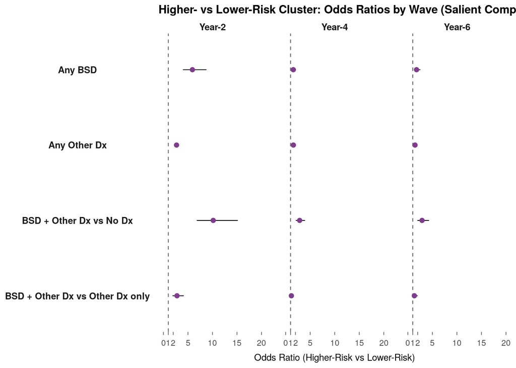

GEE: Cluster OR (High-Risk vs Low-Risk) by wave (emmeans on link scale)

| outcome | wave | contrast | log_or | se | lcl | ucl | or | or_lcl | or_ucl | p |
| --- | --- | --- | --- | --- | --- | --- | --- | --- | --- | --- |
| any_bsd | ses-02A | Higher-Risk vs Lower-Risk | 1.776 | 0.202 | 1.381 | 2.172 | 5.909 | 3.979 | 8.774 | 0.000 |
| any_bsd | ses-04A | Higher-Risk vs Lower-Risk | 0.447 | 0.150 | 0.153 | 0.742 | 1.564 | 1.165 | 2.101 | 0.003 |
| any_bsd | ses-06A | Higher-Risk vs Lower-Risk | 0.571 | 0.188 | 0.202 | 0.939 | 1.769 | 1.224 | 2.557 | 0.002 |
| bsd_only_vs_nodx | ses-04A | Higher-Risk vs Lower-Risk | 0.014 | 0.352 | -0.676 | 0.704 | 1.014 | 0.509 | 2.021 | 0.969 |
| bsd_only_vs_nodx | ses-06A | Higher-Risk vs Lower-Risk | 0.178 | 0.500 | -0.802 | 1.159 | 1.195 | 0.448 | 3.187 | 0.721 |
| bsd_only_vs_other_only | ses-04A | Higher-Risk vs Lower-Risk | -0.892 | 0.355 | -1.588 | -0.196 | 0.410 | 0.204 | 0.822 | 0.012 |
| bsd_only_vs_other_only | ses-06A | Higher-Risk vs Lower-Risk | -0.627 | 0.501 | -1.610 | 0.356 | 0.534 | 0.200 | 1.427 | 0.211 |
| bsd_plus_other_vs_nodx | ses-02A | Higher-Risk vs Lower-Risk | 2.318 | 0.205 | 1.917 | 2.719 | 10.154 | 6.798 | 15.166 | 0.000 |
| bsd_plus_other_vs_nodx | ses-04A | Higher-Risk vs Lower-Risk | 1.049 | 0.165 | 0.725 | 1.373 | 2.854 | 2.064 | 3.947 | 0.000 |
| bsd_plus_other_vs_nodx | ses-06A | Higher-Risk vs Lower-Risk | 1.063 | 0.204 | 0.663 | 1.462 | 2.895 | 1.941 | 4.317 | 0.000 |
| bsd_plus_vs_bsd_only | ses-02A | Higher-Risk vs Lower-Risk | 1.637 | 1.291 | -0.900 | 4.175 | 5.142 | 0.407 | 65.030 | 0.205 |
| bsd_plus_vs_bsd_only | ses-04A | Higher-Risk vs Lower-Risk | 1.246 | 0.421 | 0.418 | 2.073 | 3.475 | 1.519 | 7.947 | 0.003 |
| bsd_plus_vs_bsd_only | ses-06A | Higher-Risk vs Lower-Risk | 1.012 | 0.545 | -0.060 | 2.084 | 2.750 | 0.942 | 8.034 | 0.064 |
| bsd_plus_vs_other_only | ses-02A | Higher-Risk vs Lower-Risk | 1.019 | 0.206 | 0.615 | 1.423 | 2.770 | 1.850 | 4.149 | 0.000 |
| bsd_plus_vs_other_only | ses-04A | Higher-Risk vs Lower-Risk | 0.157 | 0.174 | -0.184 | 0.499 | 1.171 | 0.832 | 1.647 | 0.366 |
| bsd_plus_vs_other_only | ses-06A | Higher-Risk vs Lower-Risk | 0.278 | 0.208 | -0.130 | 0.685 | 1.320 | 0.878 | 1.984 | 0.182 |
| dx_other_any | ses-02A | Higher-Risk vs Lower-Risk | 0.983 | 0.059 | 0.868 | 1.098 | 2.673 | 2.383 | 2.998 | 0.000 |
| dx_other_any | ses-04A | Higher-Risk vs Lower-Risk | 0.455 | 0.063 | 0.330 | 0.579 | 1.575 | 1.391 | 1.784 | 0.000 |
| dx_other_any | ses-06A | Higher-Risk vs Lower-Risk | 0.380 | 0.082 | 0.219 | 0.540 | 1.462 | 1.245 | 1.716 | 0.000 |
| other_only_vs_nodx | ses-02A | Higher-Risk vs Lower-Risk | 1.010 | 0.059 | 0.894 | 1.125 | 2.745 | 2.445 | 3.081 | 0.000 |
| other_only_vs_nodx | ses-04A | Higher-Risk vs Lower-Risk | 0.508 | 0.065 | 0.381 | 0.635 | 1.662 | 1.464 | 1.888 | 0.000 |
| other_only_vs_nodx | ses-06A | Higher-Risk vs Lower-Risk | 0.420 | 0.083 | 0.256 | 0.583 | 1.521 | 1.292 | 1.792 | 0.000 |
| set_adhd | ses-02A | Higher-Risk vs Lower-Risk | 0.853 | 0.082 | 0.693 | 1.013 | 2.347 | 2.001 | 2.754 | 0.000 |
| set_adhd | ses-04A | Higher-Risk vs Lower-Risk | 0.826 | 0.103 | 0.624 | 1.028 | 2.284 | 1.866 | 2.794 | 0.000 |
| set_adhd | ses-06A | Higher-Risk vs Lower-Risk | 0.525 | 0.126 | 0.279 | 0.772 | 1.691 | 1.321 | 2.164 | 0.000 |
| set_anxiety | ses-02A | Higher-Risk vs Lower-Risk | 0.770 | 0.072 | 0.629 | 0.911 | 2.159 | 1.875 | 2.486 | 0.000 |
| set_anxiety | ses-04A | Higher-Risk vs Lower-Risk | 0.371 | 0.080 | 0.215 | 0.528 | 1.450 | 1.240 | 1.696 | 0.000 |
| set_anxiety | ses-06A | Higher-Risk vs Lower-Risk | 0.302 | 0.091 | 0.124 | 0.481 | 1.353 | 1.132 | 1.617 | 0.001 |
| set_depressive | ses-02A | Higher-Risk vs Lower-Risk | 1.185 | 0.094 | 1.002 | 1.369 | 3.272 | 2.723 | 3.931 | 0.000 |
| set_depressive | ses-04A | Higher-Risk vs Lower-Risk | 0.660 | 0.072 | 0.518 | 0.801 | 1.934 | 1.678 | 2.228 | 0.000 |
| set_depressive | ses-06A | Higher-Risk vs Lower-Risk | 0.895 | 0.109 | 0.681 | 1.110 | 2.449 | 1.976 | 3.034 | 0.000 |
| set_odd_cd | ses-02A | Higher-Risk vs Lower-Risk | 0.943 | 0.075 | 0.796 | 1.090 | 2.568 | 2.216 | 2.975 | 0.000 |
| set_odd_cd | ses-04A | Higher-Risk vs Lower-Risk | 0.753 | 0.100 | 0.557 | 0.948 | 2.123 | 1.746 | 2.581 | 0.000 |
| set_ptsd | ses-02A | Higher-Risk vs Lower-Risk | 1.612 | 0.176 | 1.267 | 1.957 | 5.012 | 3.550 | 7.075 | 0.000 |
| set_ptsd | ses-04A | Higher-Risk vs Lower-Risk | 1.258 | 0.161 | 0.944 | 1.573 | 3.520 | 2.569 | 4.822 | 0.000 |
| set_ptsd | ses-06A | Higher-Risk vs Lower-Risk | 0.809 | 0.128 | 0.559 | 1.059 | 2.246 | 1.749 | 2.885 | 0.000 |

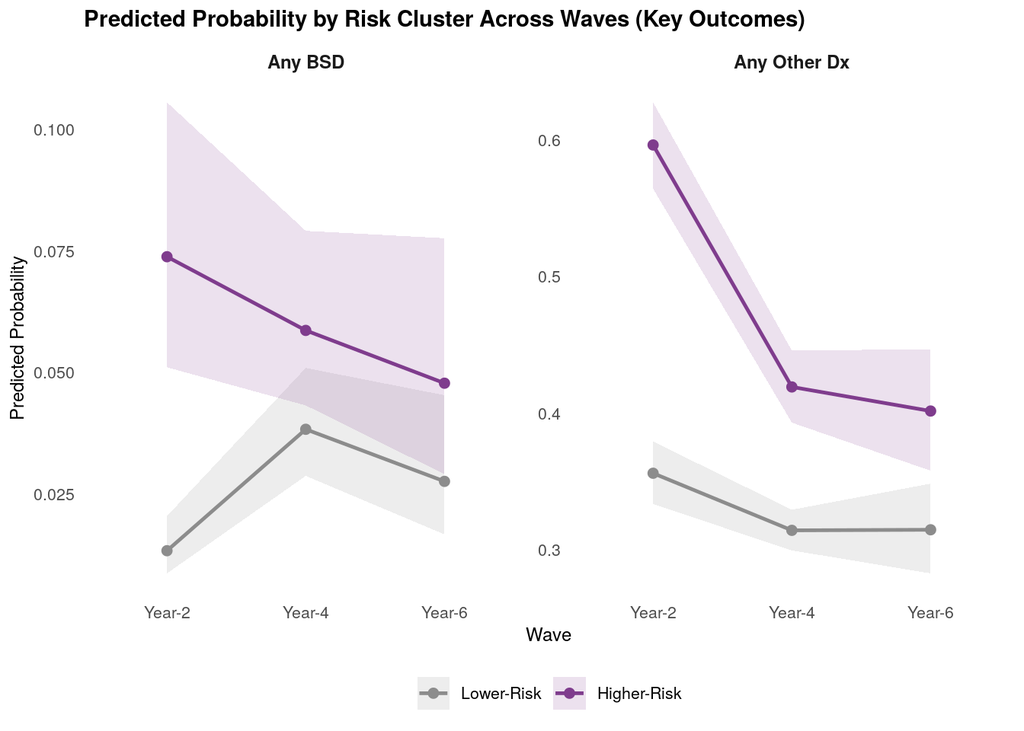

## 5.5 Disorder-Specific Comorbidity Models (Reviewer 1, Comment 4)

Cluster odds ratios (Higher- vs Lower-Risk) by wave for BSD and each comorbidity set, each from its own occurrence GEE with the same covariates and its own baseline status.

Disorder-specific GEE: cluster OR (Higher- vs Lower-Risk) by wave

| disorder | wave | or | or_lcl | or_ucl | p |
| --- | --- | --- | --- | --- | --- |
| BSD | ses-02A | 5.91 | 3.98 | 8.77 | 0.000 |
| BSD | ses-04A | 1.56 | 1.17 | 2.10 | 0.003 |
| BSD | ses-06A | 1.77 | 1.22 | 2.56 | 0.002 |
| ADHD | ses-02A | 2.35 | 2.00 | 2.75 | 0.000 |
| ADHD | ses-04A | 2.28 | 1.87 | 2.79 | 0.000 |
| ADHD | ses-06A | 1.69 | 1.32 | 2.16 | 0.000 |
| Anxiety | ses-02A | 2.16 | 1.88 | 2.49 | 0.000 |
| Anxiety | ses-04A | 1.45 | 1.24 | 1.70 | 0.000 |
| Anxiety | ses-06A | 1.35 | 1.13 | 1.62 | 0.001 |
| Depressive | ses-02A | 3.27 | 2.72 | 3.93 | 0.000 |
| Depressive | ses-04A | 1.93 | 1.68 | 2.23 | 0.000 |
| Depressive | ses-06A | 2.45 | 1.98 | 3.03 | 0.000 |
| PTSD | ses-02A | 5.01 | 3.55 | 7.08 | 0.000 |
| PTSD | ses-04A | 3.52 | 2.57 | 4.82 | 0.000 |
| PTSD | ses-06A | 2.25 | 1.75 | 2.88 | 0.000 |
| ODD/CD | ses-02A | 2.57 | 2.22 | 2.98 | 0.000 |
| ODD/CD | ses-04A | 2.12 | 1.75 | 2.58 | 0.000 |

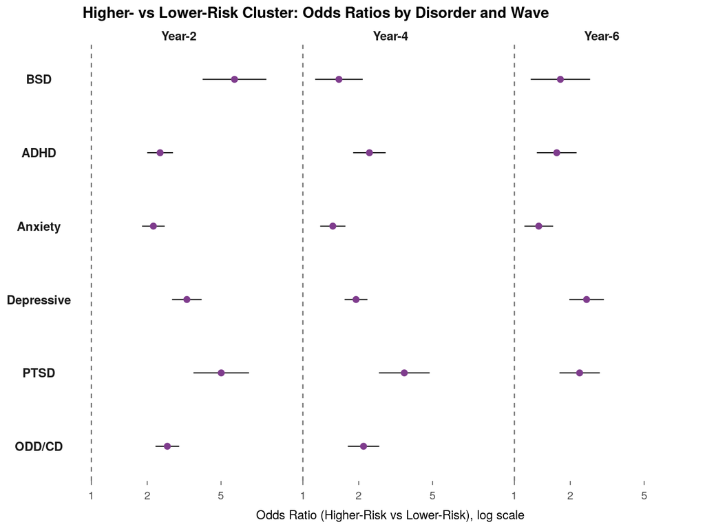

## 5.6 Stacked Specificity Test

A single GEE over long data (one row per participant x wave x disorder, for BSD and the five comorbidity sets), clustered by participant. Each disorder x wave cell has its own intercept and its own cluster coefficient, and covariates (sex, age, baseline status of that disorder) are estimated separately per disorder, so the cell-specific cluster effects parallel the separate models but share one robust covariance. That joint covariance is what allows the cluster effect for BSD to be compared formally with the cluster effect for each comorbidity, as a ratio of odds ratios (ROR > 1: the cluster difference is larger for BSD). An independence working correlation is used, as is standard when stacking distinct outcomes; inference rests on the robust (sandwich) covariance.

Stacked GEE: cluster OR (Higher- vs Lower-Risk) by disorder and wave

| disorder | wave | or | or_lcl | or_ucl | p |
| --- | --- | --- | --- | --- | --- |
| BSD | ses-02A | 5.89 | 3.97 | 8.75 | 0.000 |
| BSD | ses-04A | 1.56 | 1.16 | 2.10 | 0.003 |
| BSD | ses-06A | 1.78 | 1.22 | 2.58 | 0.002 |
| ADHD | ses-02A | 2.35 | 2.00 | 2.76 | 0.000 |
| ADHD | ses-04A | 2.28 | 1.85 | 2.79 | 0.000 |
| ADHD | ses-06A | 1.72 | 1.33 | 2.21 | 0.000 |
| Anxiety | ses-02A | 2.15 | 1.86 | 2.47 | 0.000 |
| Anxiety | ses-04A | 1.47 | 1.25 | 1.72 | 0.000 |
| Anxiety | ses-06A | 1.38 | 1.15 | 1.65 | 0.001 |
| Depressive | ses-02A | 3.26 | 2.71 | 3.92 | 0.000 |
| Depressive | ses-04A | 1.93 | 1.67 | 2.23 | 0.000 |
| Depressive | ses-06A | 2.46 | 1.98 | 3.07 | 0.000 |
| PTSD | ses-02A | 4.94 | 3.50 | 6.99 | 0.000 |
| PTSD | ses-04A | 3.61 | 2.61 | 4.98 | 0.000 |
| PTSD | ses-06A | 2.30 | 1.78 | 2.97 | 0.000 |
| ODD/CD | ses-02A | 2.60 | 2.25 | 3.01 | 0.000 |
| ODD/CD | ses-04A | 2.12 | 1.74 | 2.57 | 0.000 |

Stacked GEE: omnibus test that the cluster effect is equal across BSD and all comorbidity sets, by wave

| wave | chi_sq | df | p |
| --- | --- | --- | --- |
| ses-02A | 43.9 | 5 | 0 |
| ses-04A | 34.3 | 5 | 0 |
| ses-06A | 24.7 | 4 | 0 |

Stacked GEE: ratio of cluster ORs, BSD vs each comorbidity set (ROR > 1: larger cluster difference for BSD; p_holm adjusts within wave)

| wave | comparison | ror | ror_lcl | ror_ucl | p | p_holm |
| --- | --- | --- | --- | --- | --- | --- |
| ses-02A | BSD vs ADHD | 2.504 | 1.641 | 3.822 | 0.000 | 0.000 |
| ses-02A | BSD vs Anxiety | 2.744 | 1.829 | 4.115 | 0.000 | 0.000 |
| ses-02A | BSD vs Depressive | 1.808 | 1.245 | 2.627 | 0.002 | 0.004 |
| ses-02A | BSD vs PTSD | 1.192 | 0.723 | 1.964 | 0.491 | 0.491 |
| ses-02A | BSD vs ODD/CD | 2.267 | 1.499 | 3.429 | 0.000 | 0.000 |
| ses-04A | BSD vs ADHD | 0.685 | 0.480 | 0.978 | 0.037 | 0.150 |
| ses-04A | BSD vs Anxiety | 1.063 | 0.775 | 1.457 | 0.705 | 0.705 |
| ses-04A | BSD vs Depressive | 0.809 | 0.592 | 1.104 | 0.181 | 0.362 |
| ses-04A | BSD vs PTSD | 0.433 | 0.281 | 0.667 | 0.000 | 0.001 |
| ses-04A | BSD vs ODD/CD | 0.737 | 0.522 | 1.040 | 0.083 | 0.249 |
| ses-06A | BSD vs ADHD | 1.035 | 0.665 | 1.611 | 0.879 | 0.879 |
| ses-06A | BSD vs Anxiety | 1.290 | 0.877 | 1.898 | 0.197 | 0.590 |
| ses-06A | BSD vs Depressive | 0.721 | 0.477 | 1.090 | 0.120 | 0.482 |
| ses-06A | BSD vs PTSD | 0.771 | 0.506 | 1.176 | 0.227 | 0.590 |

## 6. Optional: Nominal Multinomial GEE for dx_group4 (if available)

If `multgee` is installed in the container, this section fits a *single* nominal GEE with `dx_group4` as the response (baseline category = “No Dx”). This is closer to the “true” multiclass problem than the pairwise binary contrasts above.

```
(multgee not installed in this environment - skipping multinomial GEE section.)
```

## 7. Notes on Interpretation

- any_bsd: aligns with the prior BD-occurrence framing (binary BSD signal).
- dx_other_any / other_only_vs_nodx: if clusters show similar magnitude effects here, that supports a *transdiagnostic* risk profile.
- bsd_only_vs_nodx: interpret cautiously (small n, especially at ses-02A). This model is best treated as exploratory.